# CM 4.3 -Resampling-based hypothesis testing

Math 530/630

# 1 Overview

- A complete knitted `html` file is due on Sakai by beginning of the next class.
- This lab is based on the assigned [ModernDive Chapter 9 and Appendix B readings](https://moderndive.org). Please open and follow closely!
- You’ll need to load these packages to do the lab (make sure they are installed first, not in your .Rmd file!):

```r
library(infer)
library(tidyverse)
library(skimr)
library(okcupiddata)
options(pillar.sigfig = 6) # you need to set this at the top of your Rmd
```

# 2 Watch

- [Bunnies, Dragons and the ‘Normal’ World: Central Limit Theorem | The New York Times](https://www.youtube.com/watch?time_continue=38&v=jvoxEYmQHNM)

# 3 Review Previous Lab

In our CM 4.2 code-along, we used data to estimate the average height of males in the US. The sample data was from the [CDC’s 2016 Behavioral Risk Factor Surveillance System (BRFSS)](https://www.cdc.gov/brfss/annual_data/annual_2016.html):

> “The Behavioral Risk Factor Surveillance System (BRFSS) is the nation’s premier system of health-related telephone surveys that collect state data about U.S. residents regarding their health-related risk behaviors, chronic health conditions, and use of preventive services.”

We started by reading in the data:

```r
# the data set is available on the course website, under References Plus
male_heights <- read_csv(here::here("data", "male_heights.csv"))
```

Then we estimated the `mean` and `sd` of US male heights using sample statistics.

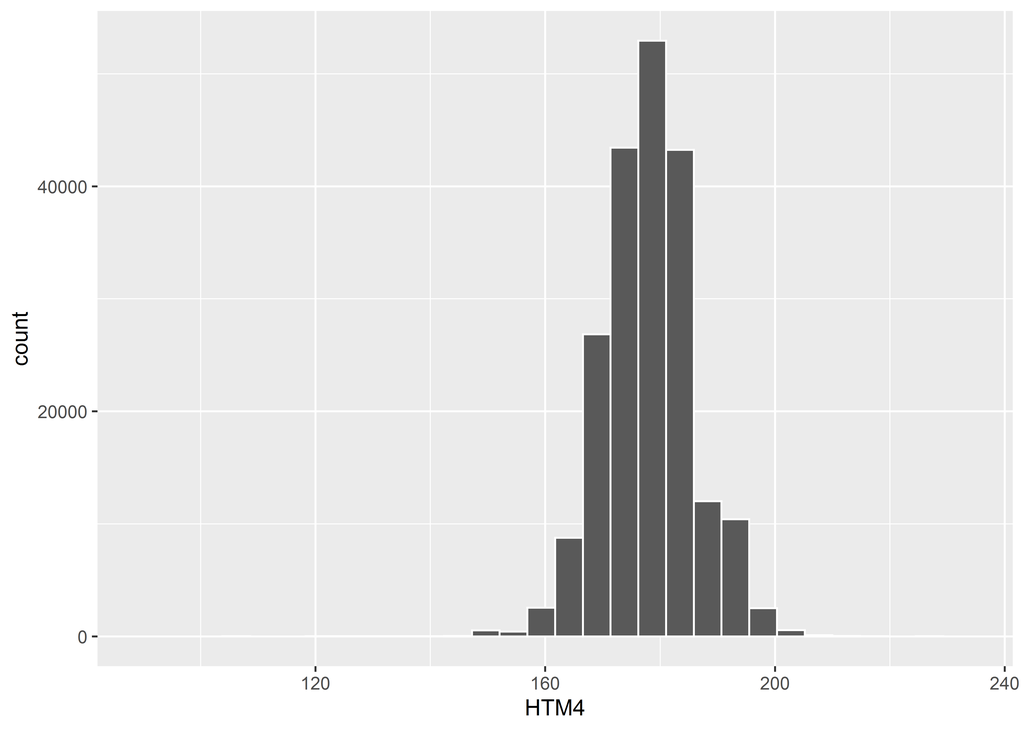

```r
ggplot(male_heights, aes(x = HTM4)) +
  geom_histogram(color = "white")
```

```r
skim(male_heights) # Because skim on windows can be unattractive
```

```
Skim summary statistics
 n obs: 204509
 n variables: 2

-- Variable type:numeric -------------------------------------------------------------------------------------------------------
 variable missing complete      n     mean       sd p0   p25   p50    p75
     HTM4       0   204509 204509   178.06     7.79 91   173   178    183
   id_num       0   204509 204509 1e+05    59036.81  1 51128 1e+05 153382
  p100     hist
   231 ▁▁▁▁▇▇▁▁
 2e+05 ▇▇▇▇▇▇▇▇
```

```r
(x_bar1 <- male_heights %>%
  summarize(stat = mean(HTM4)))
```

```
# A tibble: 1 x 1
     stat
    <dbl>
1 178.061
```

Next, we quantified the *precision* of our estimate of the mean using bootstrapping to simulate the sampling distribution of the sample mean. [Recall](https://moderndive.com/7-sampling.html#student-shovels) that sampling distributions are a specific kind of distribution: distributions of *point estimates/sample statistics* based on samples of size $n$ used to estimate an unknown *population parameter*. Here is the code used:

```r
set.seed(1701)
mh_means500 <- male_heights %>%
  specify(response = HTM4) %>%
  generate(reps = 500, type = "bootstrap") %>%
  calculate(stat = "mean")

mh_means <- mh_means500 # Or whatever number of reps your memory allowed
```

Bootstrapping the sampling distribution helps us describe how values of the sample mean of heights $\widehat{\mu}$ will vary from sample to sample due to **sampling variability** and thus identify “typical” and “atypical” values of $\widehat{\mu}$.

```r
mh_means %>%
  summarize(mean_of_means = mean(stat))
```

```
# A tibble: 1 x 1
  mean_of_means
          <dbl>
1       178.060
```

```r
(percentile_ci1 <- mh_means %>%
  get_ci())
```

```
# A tibble: 1 x 2
   `2.5%` `97.5%`
    <dbl>   <dbl>
1 178.027 178.092
```

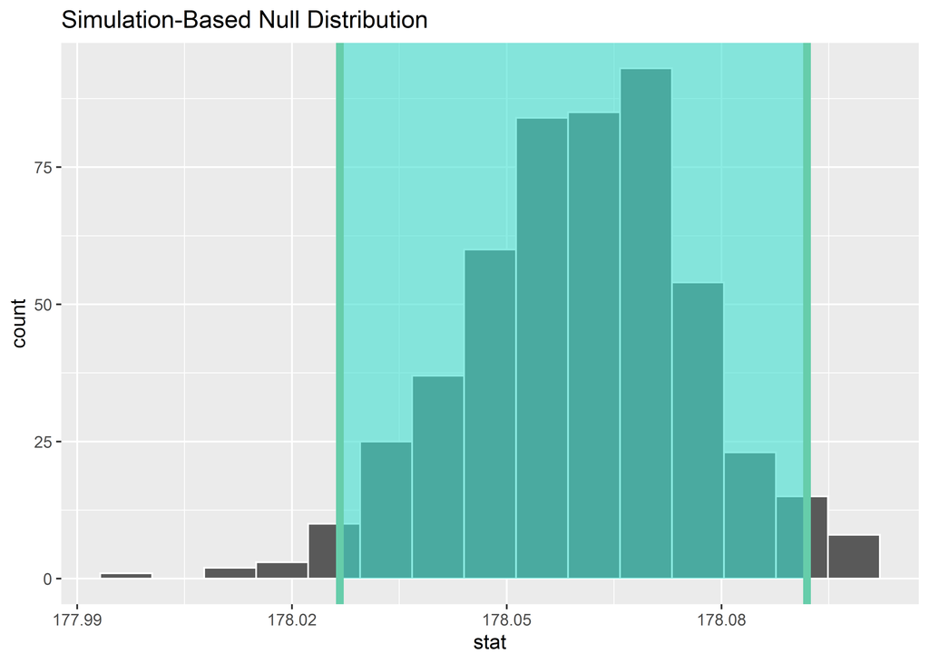

```r
mh_means %>%
  visualize() +
  shade_confidence_interval(percentile_ci1)
```

In fact, we could use `dplyr` to count how many bootstrapped means fall outside of the 95% confidence interval (the green shaded region bounded by the two green lines).

Counting the number of bootstrapped means shows that we have $13/500 = .026$ samples below the lower bound (~2.5%) CI (shaded below in red). #Note - this comes out to an even 2.5% if you use 1000 reps ;)

```r
mh_means %>%
  count(stat < pull(percentile_ci1[1]))
```

```
# A tibble: 2 x 2
  `stat < pull(percentile_ci1[1])`     n
  <lgl>                            <int>
1 FALSE                              487
2 TRUE                                13
```

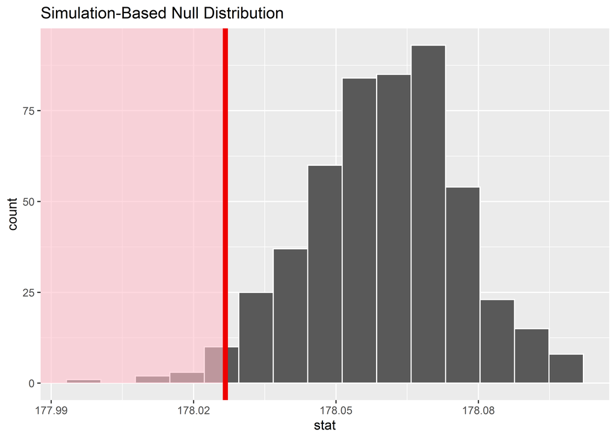

```r
mh_means %>%
  visualize() +
  shade_p_value(pull(percentile_ci1[1]), direction = "less")
```

We also count $13/500 = .026$ samples above the upper bound (~97.5%) CI.

```r
mh_means %>%
  count(stat > pull(percentile_ci1[2]))
```

```
# A tibble: 2 x 2
  `stat > pull(percentile_ci1[2])`     n
  <lgl>                            <int>
1 FALSE                              487
2 TRUE                                13
```

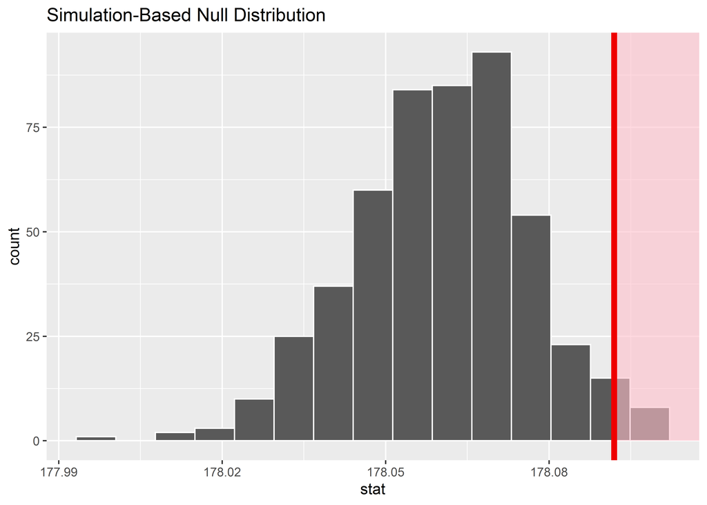

```r
mh_means %>%
  visualize() +
  shade_p_value(pull(percentile_ci1[2]), direction = "greater")
```

So, our original sample mean was 178.06. We used bootstrapping to quantify the precision of that sample estimate. Finally, we used `infer::get_ci(type = "percentile")` to calculate the range of “stats” (here, sample means) that encompasses 95% of the bootstrapped samples- > 5% of our bootstrapped samples produce means that fall outside of this range.

# 4 Key Questions

See [Chapter 7 in ModernDive](https://moderndive.com/7-sampling.html#concepts-related-to-sampling).

Referring to the BRFSS data analyzed in above, answer the following questions:

1. Population: Who is the population of interest that we want to say something about?
2. What is the population parameter of interest?
   - Hint: https://moderndive.com/8-confidence-intervals.html
3. Census: What would a census be in this case?
4. Sampling: How do you acquire the sample of size $n$ observations? What is the sample size $n$?
5. Point estimates/sample statistics: What is the summary statistic based on the sample of size $n$ that estimates the unknown population parameter?
   - Hint: https://moderndive.com/8-confidence-intervals.html
6. Representative sampling: Is the sample procedure representative? In other words, do you believe the resulting samples “look like” the population?
7. Random sampling: Was the sampling random?
   - Follow-up question: if you took another sample using the exact same methods, do you think you would get the *exact* same sample statistic?
8. Where is the sampling distribution centered?
9. What is the spread of this sampling distribution?
10. Complete these two sentences:

> Assuming that this sample is representative of all males in the US, we are 95% confident that the average height for males in the US is between —- and —- centimeters.

> Assuming that this sample is representative of all males in the US, if we were to collect 500 random samples using the exact same sampling method, in 95% of *those* samples (i.e., 475 out of 500), the average height for males in the US would be between —- and —- centimeters.

# 5 “OKCupid” sample

In this lab, you’ll use a second different sample to estimate the average height of US males. This sample was taken from male volunteer users of the dating website “OKCupid” living in the San Francisco area. Heights are self-reported in inches. Use the code provided to load the `profiles` from the `okcupiddata` R package. This code filters for all males, converts height to centimeters, drops missing values, and take a random sample of $n$ = 45 observations.

```r
library(okcupiddata)
set.seed(2018)
cupid <- profiles %>%
  filter(sex == "m") %>%
  mutate(height = 2.54*height) %>%
  drop_na(height) %>%
  sample_n(45) %>%
  select(height) %>%
  remove_rownames()
```

# 6 Bootstrapping for hypothesis test

Follow along in [ModernDive, Appendix B.2.4](http://moderndive.com/b-appendixb).

Using the “OKCupid” sample data described above, we’ll use bootstrapping to evaluate the following competing hypotheses:

## 6.1 In words

- Null hypothesis: The mean height for all US men is equal to 178.06 cm (as we found above)
- Alternative hypothesis: The mean height for all US men is greater than 178.06 cm.

## 6.2 In symbols (with annotations)

- $H_0: \mu = \mu_{0}$, where $\mu$ represents the mean height for all US men and $\mu_0$ is 178.06.
- $H_A: \mu > 178.06$

**Think:** if the population mean *were* 178.06, how surprised would I be to get a sample mean as or more extreme than the one I got?

## 6.3 The bootstrap approach

First step is to calculate the sample mean height using yourOkCupid sample.

```r
(cupid_bar <- cupid %>%
  summarize(stat = mean(height)))
```

```
      stat
1 180.7916
```

In order to see if the observed sample mean of 180.79 is statistically greater than $\mu_0 = 178.06$, we need to account for the sample size. We also need to determine a process that replicates how the sample of size 45 was selected.

We can use the idea of *bootstrapping* to simulate the population from which the sample came and then generate samples from that simulated population to account for sampling variability. Recall how bootstrapping would apply in this context:

1. Sample with replacement from our OKCupid sample of 45 men and repeat this process 1,000 times (try `set.seed(2018)`),
2. Calculate the mean for each of the 1,000 bootstrap samples created in Step 1.,
3. Combine all of these bootstrap statistics calculated in Step 2 into a `boot_distn` object, and
4. Shift the center of this distribution over to the null value of 178.06. (This is needed since it will be centered at 180.79 via the process of bootstrapping.)
5. Use this distribution to observe our $p$-value. Recall this is a right-tailed test so we will be looking for values that are greater than or equal to 180.79 for our $p$-value.

**Hint:** With 2018 as my seed, I got a p-value of 0.005 with 1000 reps; and a p-value of 0.0062 with 10,000 reps.

# 7 Bootstrapping for a confidence interval

Follow along in [ModernDive, Appendix B.2.4](https://moderndive.com/B-appendixB.html#non-traditional-methods).

> Assuming that this sample is representative of all males in the US, we are 95% confident that the true average height for males in the US is between —- and —- centimeters.

# 8 Two means (independent samples) (on your own)

Follow along with the [ModernDive Chapter 9](http://moderndive.com/9-hypothesis-testing.html#example-comparing-two-means) and [ModernDive Appendix B.5](http://moderndive.com/b-appendixb) (search for the section titled: “Two means (independent samples)”).

Use this [kaggle dataset](https://www.kaggle.com/hakabuk/us-presidents-heights-how-low-can-u-go), and test whether there is a difference in mean heights between men on the “OKCupid” dating site, versus all our POTUSes. Use a randomization test, which is a resampling-based method also called a permutation test. From ModernDive:

> “We can use the idea of randomization testing (also known as permutation testing) to simulate the population from which the sample came (with two groups of different sizes) and then generate samples using shuffling from that simulated population to account for sampling variability.”

FYI - The dataset is one the course web site, under [Reference Plus/data](https://ohsu-math630-fall-2019.netlify.com/reference.html):

```r
pres <- read_csv(here::here("data", "president_heights_new.csv")) %>%
  select(height = `height(cm)`)

cupid_pres <- cupid %>%
  bind_rows(pres, .id = "sample") %>%
  mutate(sample = as.factor(sample))
```